| Black Lake | Black Lake Association | Town(s) of Hammond | St. Lawrence County |
| --- | --- | --- | --- |

[figure not shown]

## Black Lake – 2018 Sampling Season Results

Open Water Indicators

2018 Sampling Results

Seasonal Change

Season Avg

Decadal Average

Decadal Trend?

Longterm Avg

Longterm Trend?

05-28

06-10

06-22

07-07

07-20

08-04

08-18

09-02

Clarity (m)

1.9

2.4

2.1

1.4

1

0.8

0.8

0.8

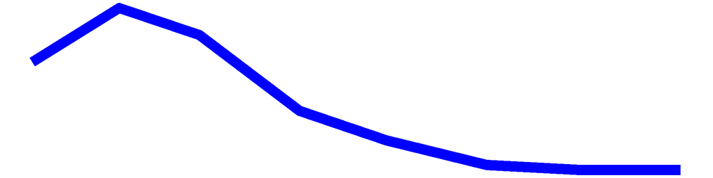

1.4

1.7

1.6

Surface TP (mg/L)

0.031

0.035

0.035

0.05

0.061

0.06

0.068

0.028

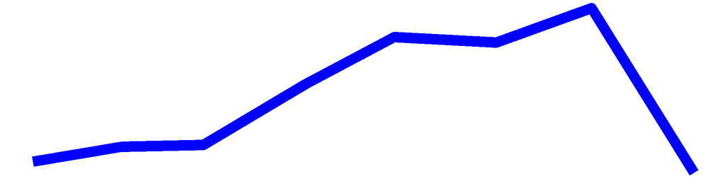

0.047

0.048

0.042

Surface TDP (mg/L)

0.019

0.015

0.019

0.029

0.021

0.032

0.047

0.022

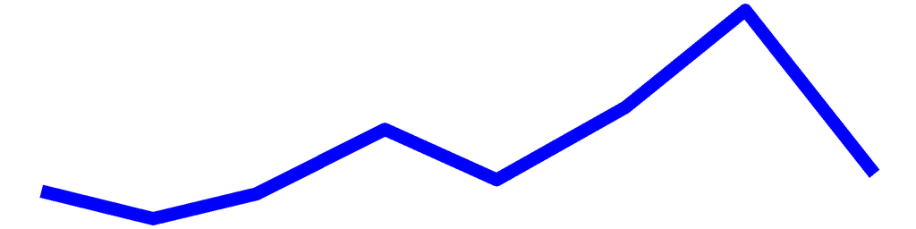

0.025

TN (mg/L)

0.58

0.544

0.7

0.712

1.047

1.086

1.155

0.992

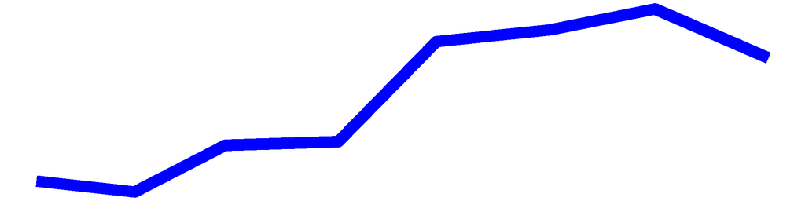

0.82

0.793

0.727

TDN (mg/L)

0.532

0.539

0.693

0.694

0.901

0.922

1.03

0.784

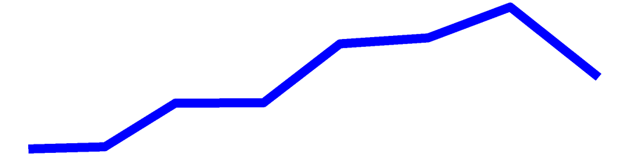

0.762

0.586

0.586

TN:TP

19

16

20

14

17

18

17

35

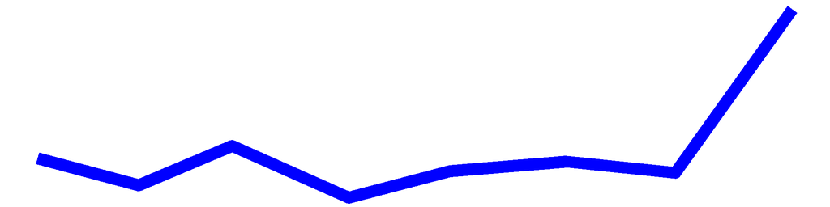

21

19

20

Surface NH3 (mg/L)

0.16

0.02

0.03

0.043

0.308

0.179

0.246

0.211

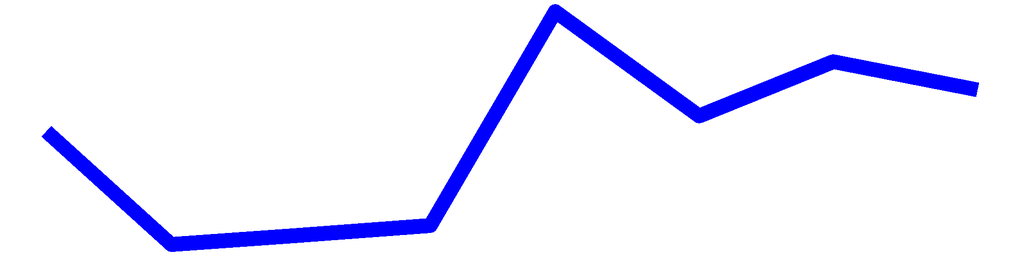

0.15

0.04

0.038

Chl.a (ug/L)

7.9

6

12.6

32.6

50.9

44.1

76.3

55.4

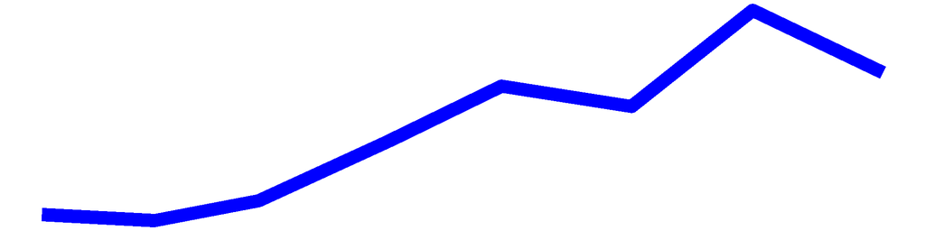

36.9

20.6

23.7

pH

7.9

8.1

7.8

8.4

8.4

8.4

7.9

8.1

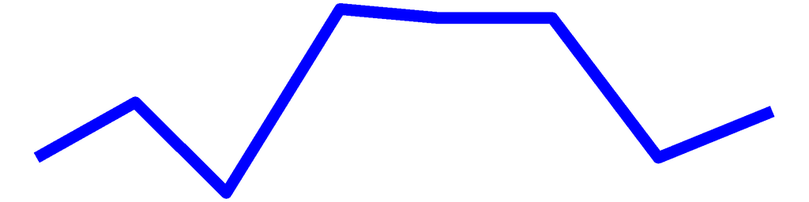

8.1

8

8

Cond (umho/cm)

198

193

140

218

257

225

236

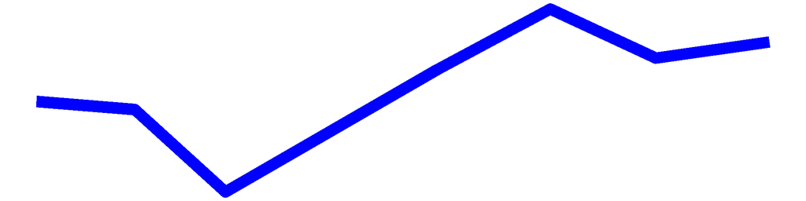

209

178

162

Surface Chloride (mg/L)

29

29

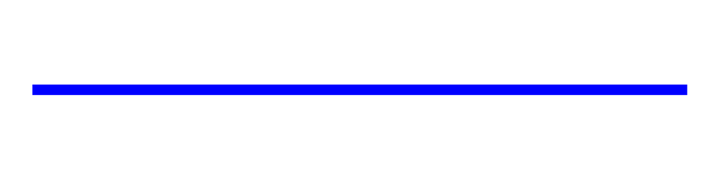

29

21

21

Upper Temp (degC)

25

25

26

30

30

30

28

27

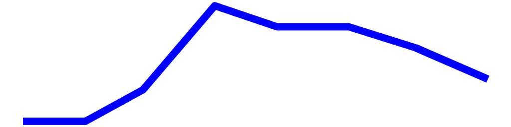

28

25

23

FP BG Chl.a (ug/L)

0

1.4

11.8

46

8.9

50.9

65.3

39.5

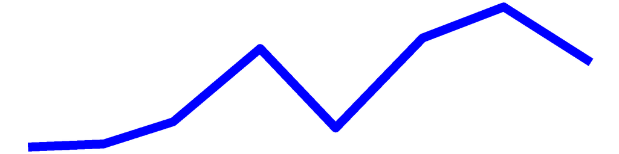

28

16.4

16.4

### NYHABs notifications

#### Were there any reported HABs this season? **Yes.**

| Date of First Listing | Date of Last Listing | Number of Reports |
| --- | --- | --- |
| 07/07/2018 | 09/02/2018 | 255 |

### Shoreline HAB Sample Dates 2018

| HAB Indicators | Criteria | 08-04 |
| --- | --- | --- |
| FP BGA Chl. a | 25 ug/L | 369.8 |
| Microcystin | 20 ug/L | 10 |
| Microscopy | Dominant | Fragilaria, Ceratium, Filamentous green algae |

### HABs Status

#### Open Water Algae

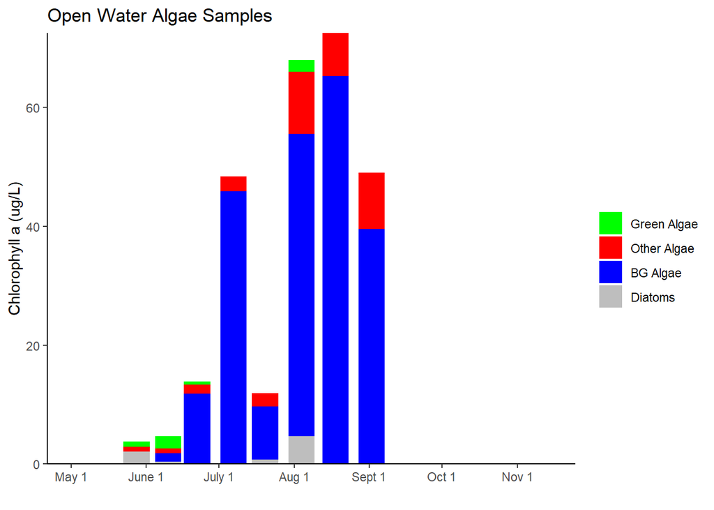

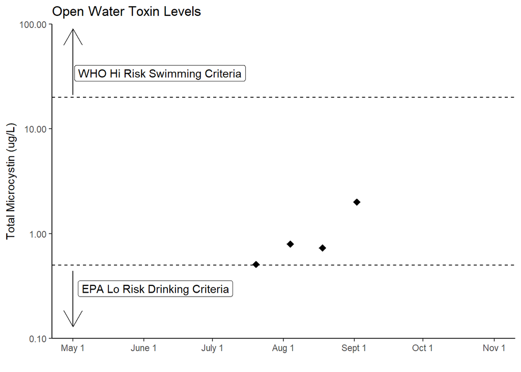

#### Shoreline Algae

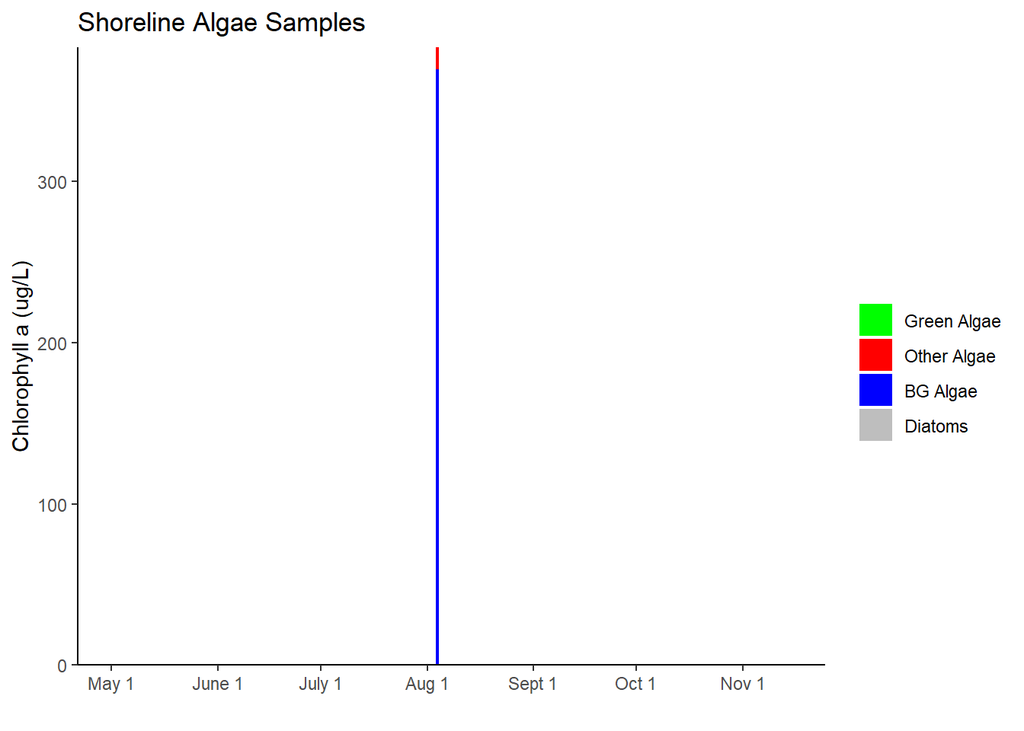

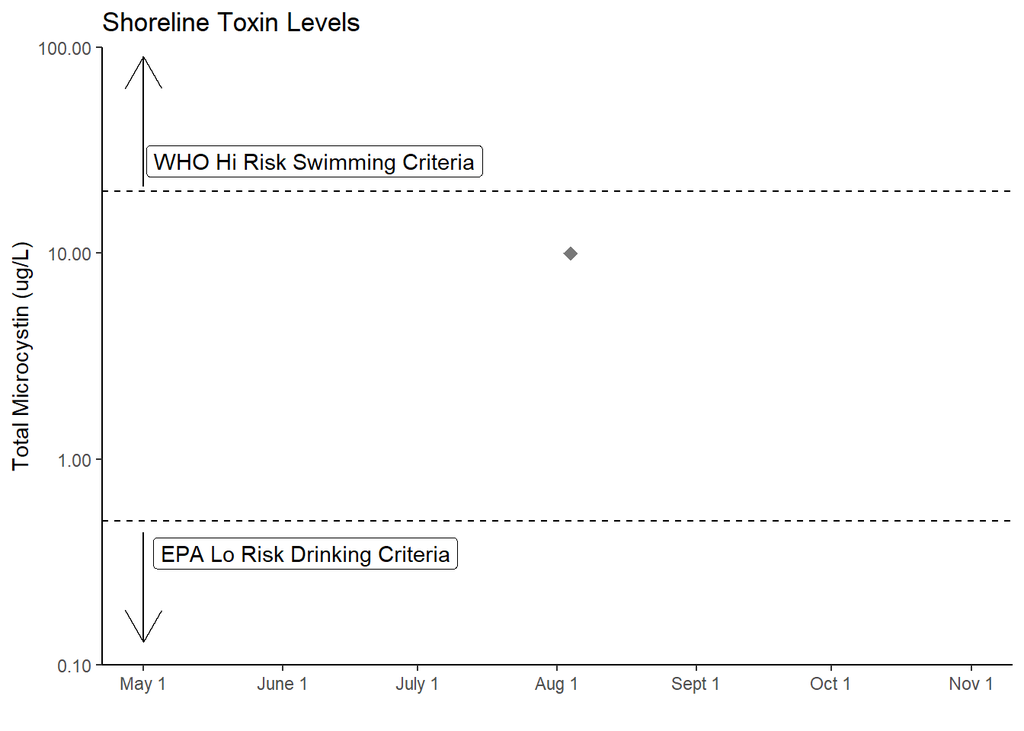

## Black Lake Long-Term Trend Analysis

#### Clarity

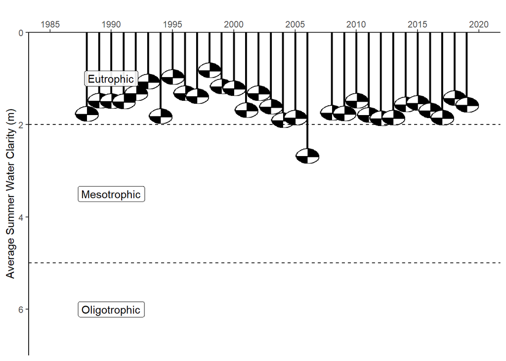

#### Chlorophyll *a*

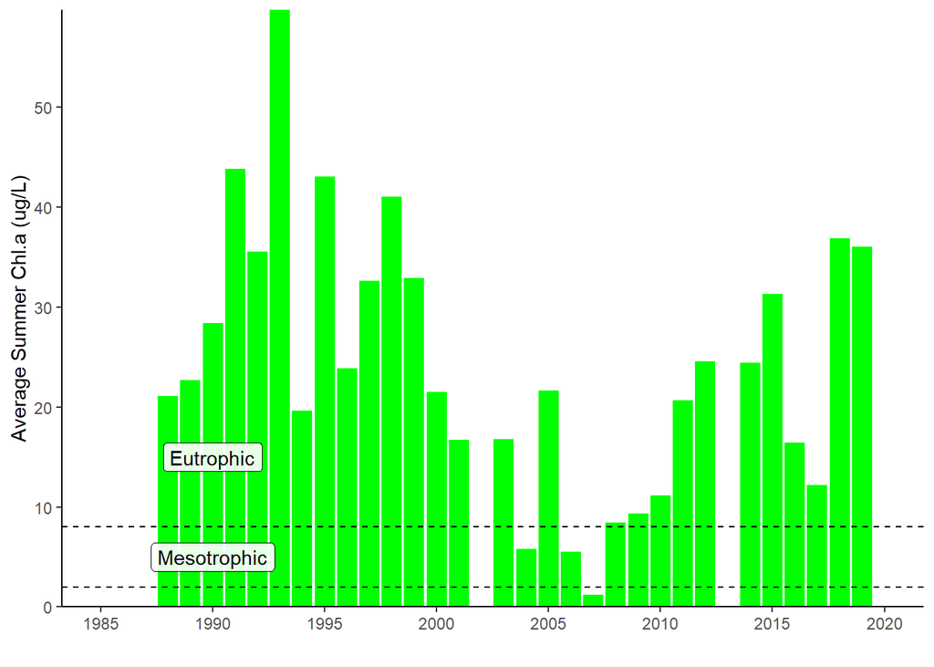

#### Surface and Deep Phosphorus

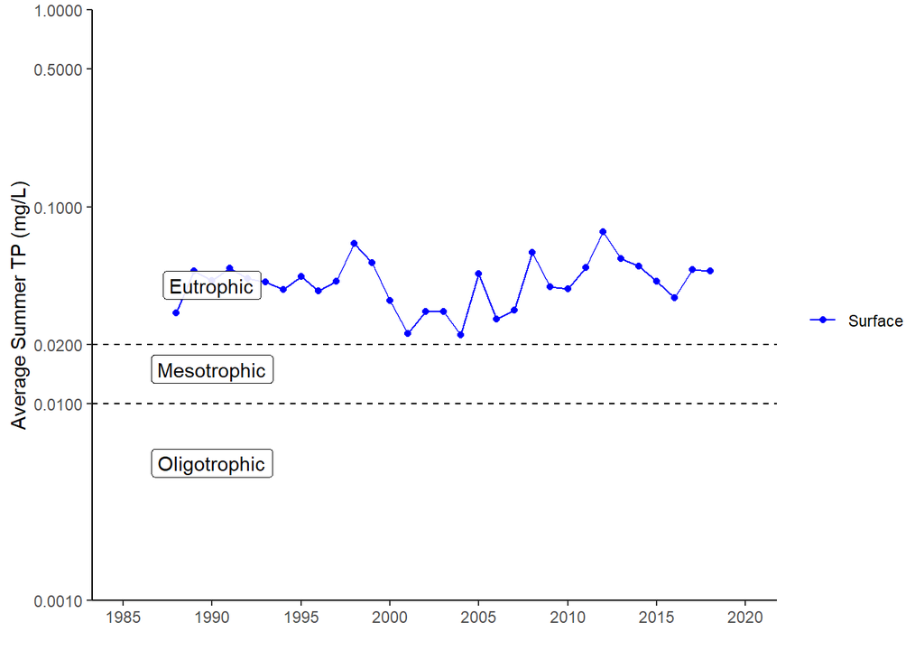

#### Nitrogen

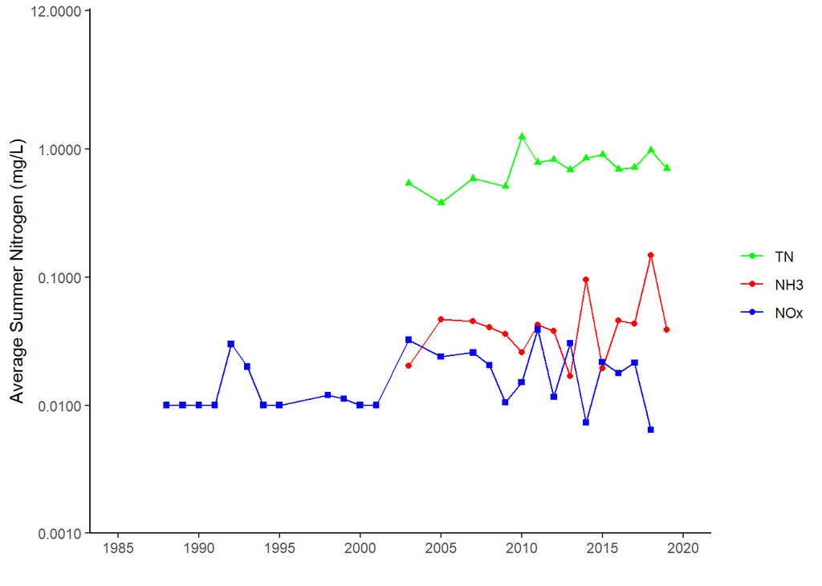

#### TN : TP

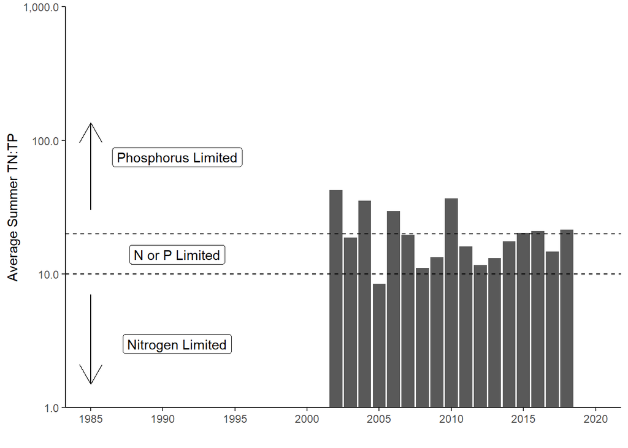

#### pH

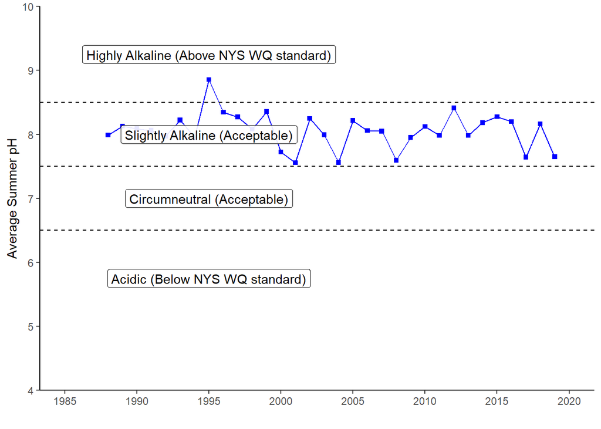

#### Specific Conductance

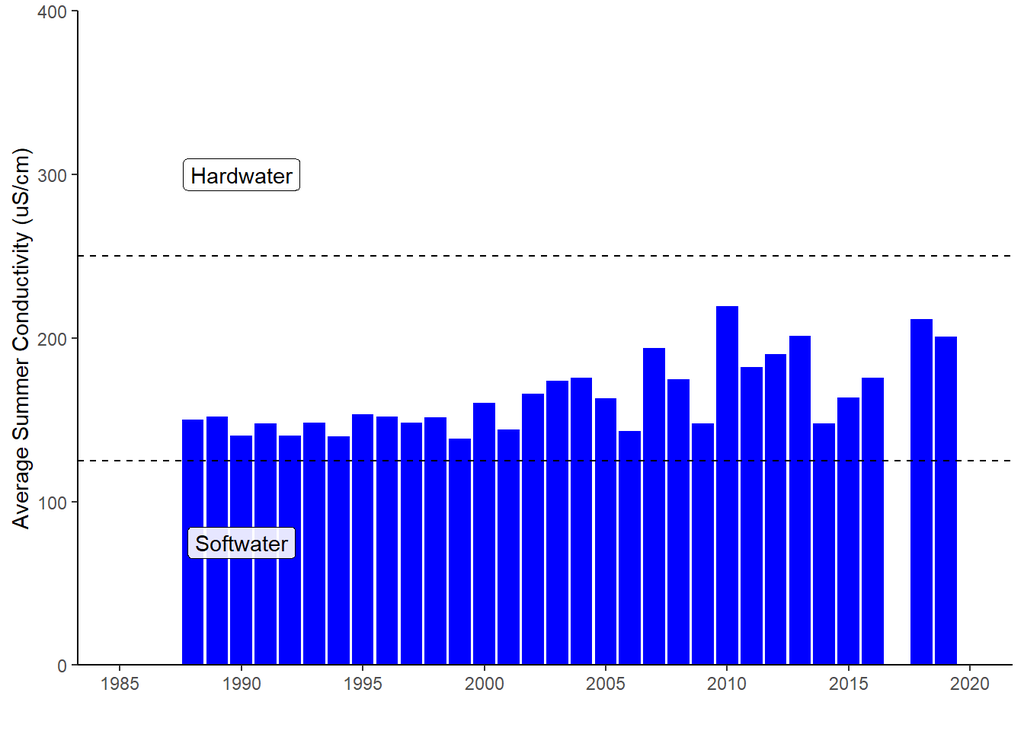

#### Calcium

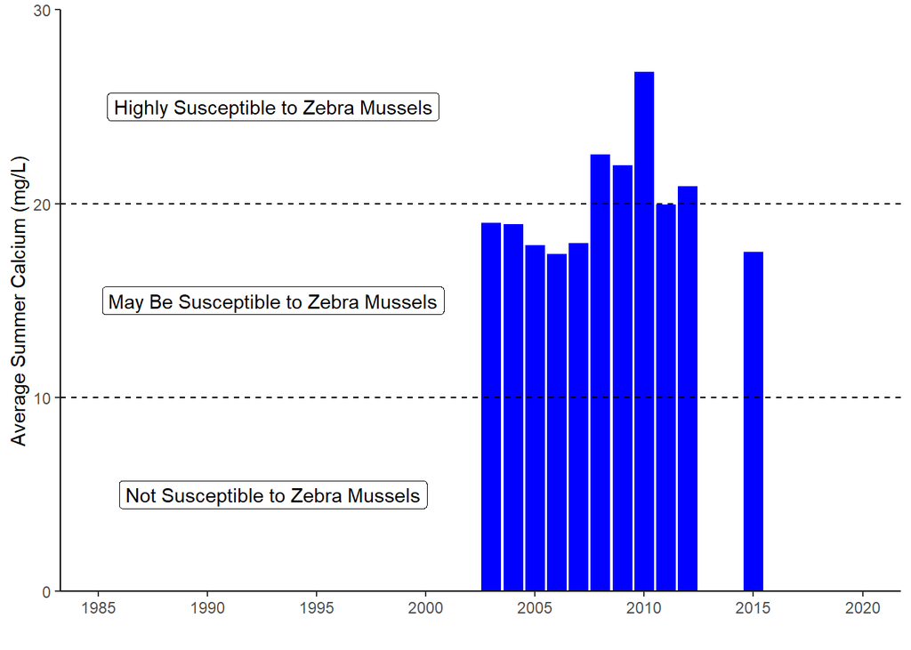

#### Chloride

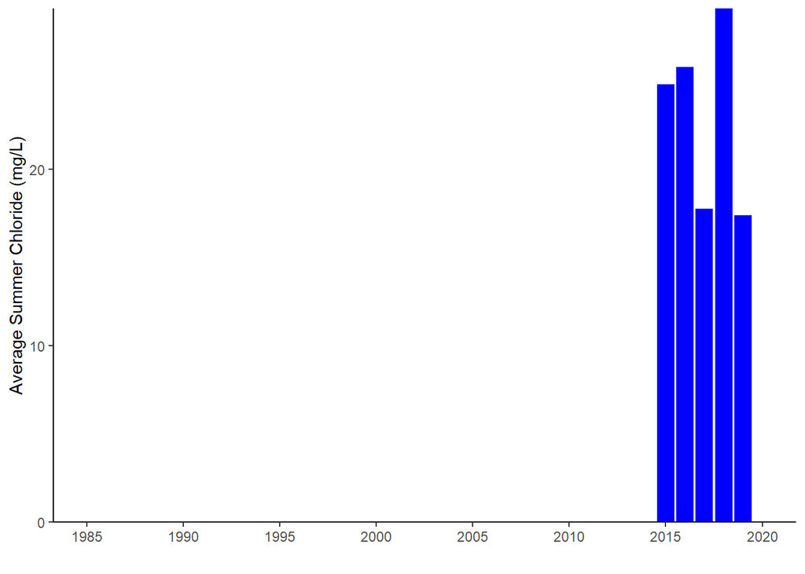

#### Color

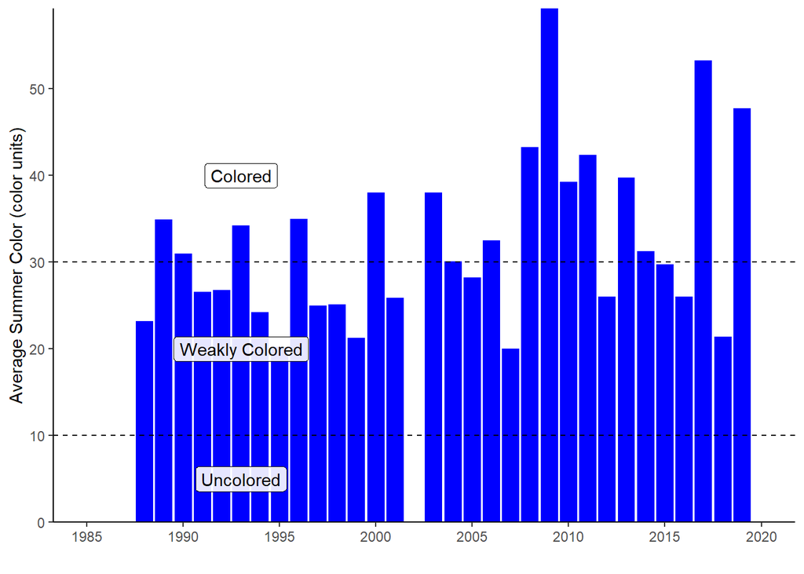

#### Surface and Deep Temperature

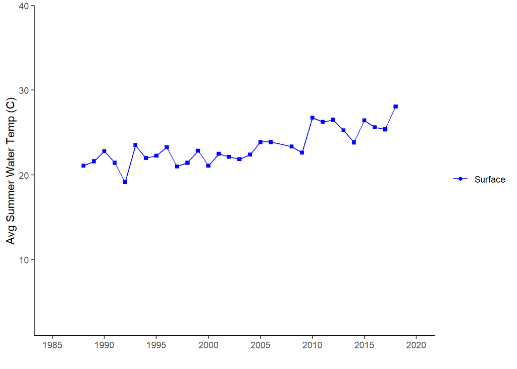

#### Lake Perception

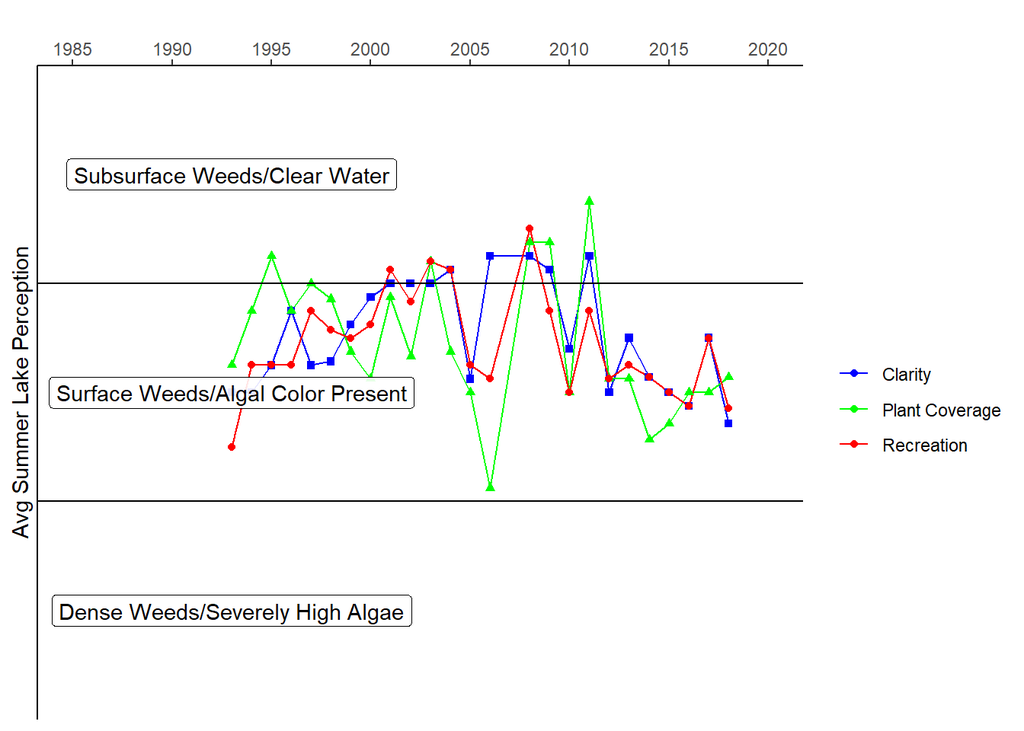

## Black Lake - In-Season Analysis

#### In Season Water Clarity

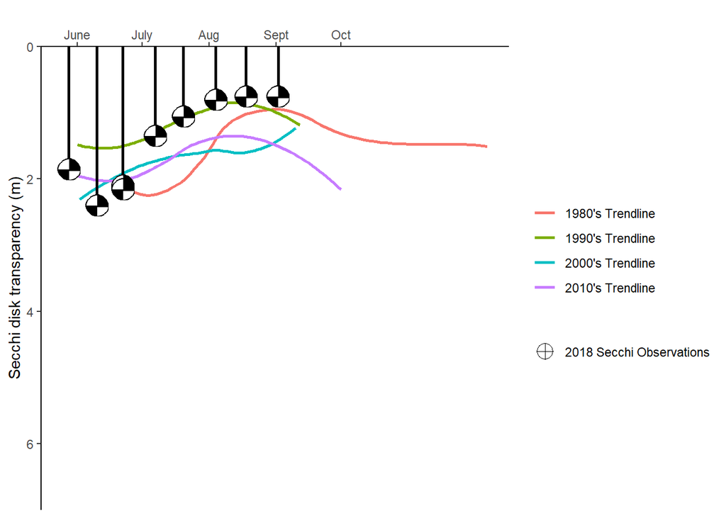

#### In Season Water Temperature

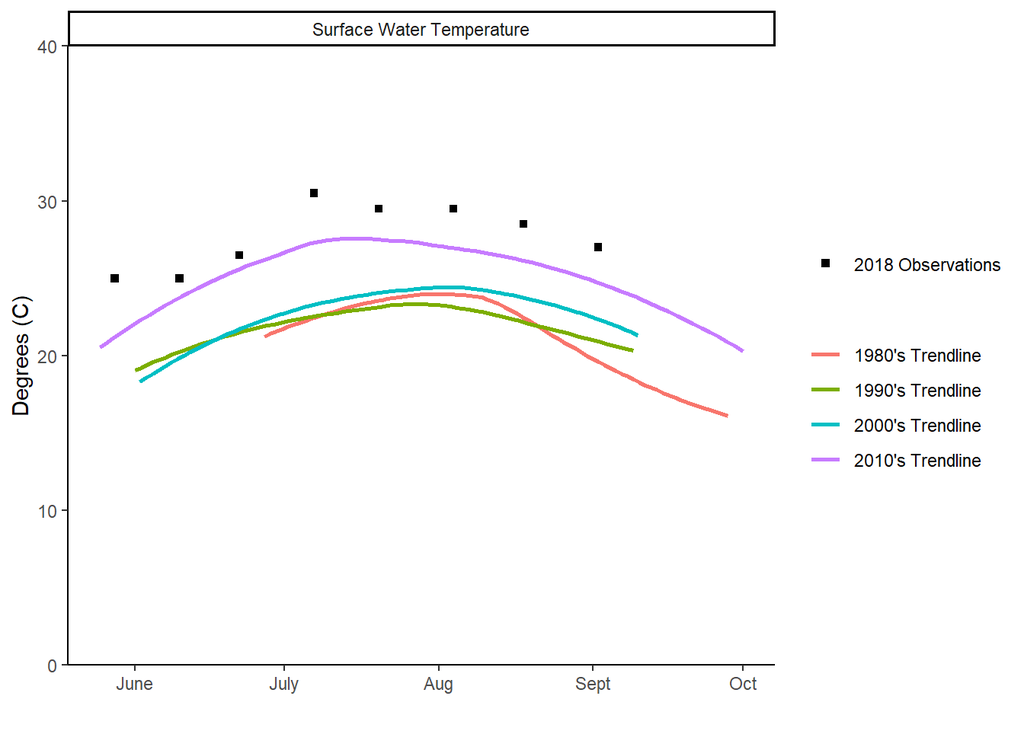

### Black Lake – Lake Scorecard

```
## [1] 1
```

```
## [1] 1
```

[output not shown]

| Aquatic Invasive Species | Present |
| --- | --- |